# Exercise 11

Martin Holub

2 11 2017

## Load the micro-RNA expression data

The package MLSeq has some micro-RNA expression data from normal (N) and tumor samples (T). These can be loaded with

```r
cervicalFile = system.file("extdata/cervical.txt", package = "MLSeq", mustWork = TRUE)
cervicalCounts = as.matrix(read.table(cervicalFile, header = TRUE))
head(cervicalCounts)
```

```
##          N1   N2   N3    N4   N5  N6 N7   N8   N9   N10  N11   N12   N13
## let-7a  865  810 5505  6692 1456 588  9 4513 1962 10167 4113  2610  5008
## let-7a*   3   12   30    73    6   2  0  199   10   173   30   105    71
## let-7b  975 2790 4912 24286 1759 508 33 6162 1455 18110 8862 12481 21641
## let-7b*  15   18   27   119   11   3  0  116   17   233   40   180   288
## let-7c  828 1251 2973  6413  713 339 23 2002  476  3294 5929  1816  3278
## let-7c*   0    0    0     1    0   0  0    3    0     3    0     0     3
##          N14 N15   N16   N17   N18   N19   N20   N21   N22  N23  N24  N25
## let-7a   580 667  6731  3671  3276  4910  5876  3877  7516 4930 3755  267
## let-7a*   21   7   738  1051   476   568   643   175   767   48   76    3
## let-7b  8320 918 43582 33730 40209 80226 55768 31744 71032 5486 6932 1162
## let-7b*   63  12   468   479   396   470   686   129   673   65   83   18
## let-7c   573 303  4670  2203  3096  5162  4537  3217  5675 1411 3477  371
## let-7c*    0   0    20     2     6     1    18     6    11    1    5    1
##           N26   N27  N28 N29   T1    T2   T3   T4   T5  T6   T7  T8   T9
## let-7a  56824 16115 5293  38 3343  4990 5193 1464 5342 434 1502  34 2390
## let-7a*   237   103  100  14   12    99   15   12   32   0   18   4   19
## let-7b  59593 15126 5949 103 4217 41617 5152 2536 4551 980 3398 102 2220
## let-7b*   430   155   64 194    8   148   14    8   29   5    5   2   16
## let-7c  37225 10206 2966  25  519  4664 1274  297  673 749  168  28  584
## let-7c*     4     0    0   0    0     3    0    0    0   0    0   0    0
##          T10 T11   T12  T13    T14  T15 T16  T17 T18   T19 T20    T21 T22
## let-7a  3996 687  1780 1030   3459 2520 314 1512 447  2744  37   3174 116
## let-7a*   22   1    58   18    732   88  42   98   5   184   0    648   4
## let-7b  5404 995 12729 3030 108332 6996 938 5685 654 15489  99 102358 184
## let-7b*   24   3    54    4    308   49  12   51   8   106   0    334   1
## let-7c  4118 999  2210 1697   5775 2839 130  762 157   974  34   1711  22
## let-7c*    0   0     3    0      8    2   0    0   0     1   0      4   0
##           T23 T24   T25   T26   T27 T28  T29
## let-7a   1722  68 12121 14398 39196 198 1422
## let-7a*   212   6     2    80   164  18    1
## let-7b  28274 401 14471 24097 73139 669 2492
## let-7b*   189   5    34   115   230   4   15
## let-7c   3127 199  3186  1454  5883 167  321
## let-7c*     2   0     0     1     1   0    0
```

The true class for each sample is given by

```r
cervicalClass = factor(substr(colnames(cervicalCounts), 1,1))
head(cervicalClass)
```

```
## [1] N N N N N N
## Levels: N T
```

## Normalization

Use edgeR’s TMM normalization to normalize the counts. Use the log-transformed counts-per-million values with a `prior.count=10`.

```r
y_dge <- edgeR::DGEList(counts = cervicalCounts, group = cervicalClass)
y_dge <- edgeR::calcNormFactors(y_dge, method = "TMM") # adjust for different sizes of libraries
y <- edgeR::cpm(y_dge, normalized.lib.sizes = TRUE, log = TRUE, prior.count = 10)
```

## Visualization

Create an MDS plot to get an idea of the separability of the samples.

Dim-reduced data looks reasonably well separable by linear classifier.

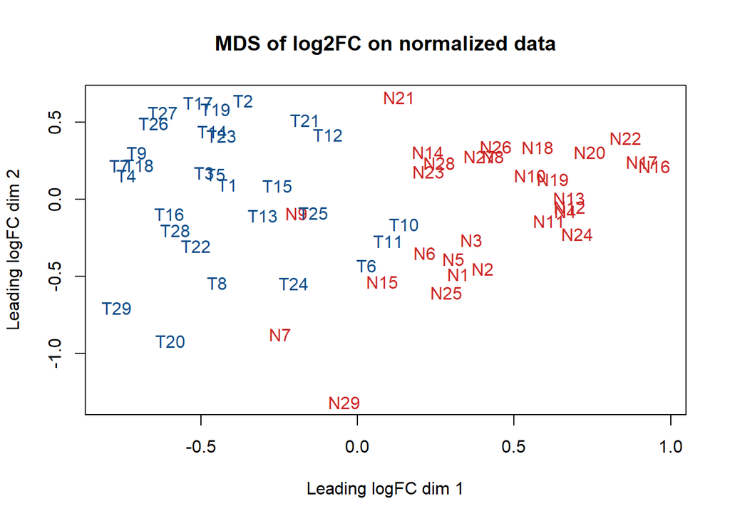

```r
# this one does also the normalization and then passes to limma::plotMDS. We normalize manually and use limma directly
# edgeR::plotMDS.DGEList(y, top = 500, method = "logFC", prior.count = 10)

farbs <- rep('firebrick3', length(cervicalClass))
farbs[cervicalClass == 'T'] <- 'dodgerblue4'

limma::plotMDS(y, top = 500, col = farbs, main = "MDS of log2FC on normalized data")
```

## Nonspecific filtering

In order to reduce the dimensionality, Use only those micro-RNAs where the row variance is larger then 0.5. (basic feature selection.)

```r
var_thresh = 0.5
y <- y[apply(y, 1, var) > var_thresh, ]
```

## k-nn classification

Implement a k-nn classification with cross-validation use the function `knn.cv` from the package `class`.

*This uses leave-one-out cross validation. For each row of the supplied data, the k nearest (in Euclidean distance) other training set vectors are found, and the classification is decided by majority vote, with ties broken at random. If there are ties for the kth nearest vector, all candidates are included in the vote.*

```r
class_res <- class::knn.cv(t(y), cervicalClass, l = 3, k = 5, prob = TRUE)
#class_res <- class_res[lapply(class_res, 1, function(x) !any(is.na(x) )), ]
```

Compute the f1-score.

```r
f1_score_fun <- function(labels, ground_truth){

  positive_class <- levels(ground_truth)[2]
  negative_class <- levels(ground_truth)[1]

  TP <- sum((ground_truth == positive_class) == (labels == positive_class))
  FP <- sum((ground_truth == positive_class) != (labels == positive_class))
  TN <- sum((ground_truth == negative_class) == (labels == negative_class))

  precision <- TP / (TP + FP)
  recall <- TN / (TN + FP)
  f1 <- 2 * (precision * recall / (precision + recall))

  output <- list (f1, precision, recall)
  return(output)
}

f1_score <- f1_score_fun(class_res, cervicalClass)[1]
f1_score
```

```
## [[1]]
## [1] 0.9827586
```

The `f1_score` is 0.9827586, where 1 is perfect classification and 0 the worst one.

## MLInterfaces

Implement the same scheme using the MLInterfaces package., and using knn.cv’s internal cross-valdiation scheme. For that the data needs to be casted in a variable of class `ExpressionSet`

```r
library(MLInterfaces)
# Generate new object of class  `ExpressionSet`
cervES <- new("ExpressionSet", exprs = y, phenoData=AnnotatedDataFrame(y_dge$samples))
```

The k-nn classifier with cross-validation is now implemented as

```r
library(MLInterfaces)
# We will transpose the data and cast it to dataframe
exprs.df <- as.data.frame(t(cervES@assayData$exprs))
knn1 <- MLInterfaces::MLearn(formula = cervicalClass~., data = exprs.df, .method = MLInterfaces::knn.cvI(k = 5, l = 3), trainInd =(1:ncol(cervES)))

MLInterfaces::confuMat(knn1)
```

```
##      predicted
## given  N  T
##     N 29  0
##     T  1 28
```

```r
f1_score_fun(knn1@testPredictions, cervicalClass)[1]
```

```
## [[1]]
## [1] 0.9827586
```

Setup a balanced k-fold cross-validation scheme

**From here on, I run into issues with MLInterfaces. Although the underlying classifiers work in their respecitve evnironments, they will fail to produce result when wrapped within the MLInterfaces. I tried running the code both on Linux and Windows. I address the problem by using the underlying classifers to obtain ressults. I compute F1 score as a metric of performance.**

**The fact that the package was not working for me, increased the amount of time necessary for the exercise. I have tried multuiple ways how to debug it but to no avail. Despite these problems I managed to produce results as required. I would like to ask you to consider this fact when grading and do not immediately subtract points for usage of different approach.**

*If you immediately see what may have gone wrong, I will be happy to hear feedback.*

```r
# Does not work!
k = 10
#knnCV <- MLInterfaces::MLearn(formula = cervicalClass~., data = exprs.df, .method = MLInterfaces::knnI(k = 5, l = 3),
#                            trainInd = MLInterfaces::xvalSpec("LOG", k, MLInterfaces::balKfold.xvspec(k)))

exprs.dft <- as.data.frame((cervES@assayData$exprs))
set.seed(101) # Set Seed so that same sample can be reproduced in future also
# Now Selecting 50% of data as sample from total 'n' rows of the data
sample <- sample.int(n = ncol(exprs.dft), size = floor(.5*ncol(exprs.dft)), replace = F)
train <- data.matrix(exprs.dft[, sample])
test  <- data.matrix(exprs.dft[, -sample])
knnCV <- class::knn(t(train), t(test), (cervicalClass[sample]), k = 5, l = 3, prob = TRUE)

#MLInterfaces::confuMat(knnCV)
# Get F1 score on test set
f1_score_fun(knnCV, cervicalClass[-sample])[1]
```

```
## [[1]]
## [1] 0.8965517
```

## Other classifiers

Compute the performance of the diagonal linear discriminant analysis and support vector machines provided by MLInterfaces.

```r
# Doesnt work
#diagDA_res = MLInterfaces::MLearn(cervicalClass~.,exprs.df, MLInterfaces::dldaI, trainInd =(1:ncol(cervES)))

trueLabels <- rep(1, length(cervicalClass))
trueLabels[cervicalClass == 'T'] <- 2
diagDA_res <- sfsmisc::diagDA(exprs.df, trueLabels, exprs.df, pool = TRUE)
diagDA_res[diagDA_res == 2] <- 'T'
diagDA_res[diagDA_res == 1] <- 'N'
diagDA_res <- factor(diagDA_res)

#MLInterfaces::confuMat(diagDA_res)
f1_score_fun(diagDA_res, cervicalClass)[1]
```

```
## [[1]]
## [1] 0.9655172
```

```r
# Doesnt work
#svm_res = MLInterfaces::MLearn(cervicalClass~.,exprs.df, MLInterfaces::ksvmI, trainInd =(1:ncol(cervES)))

trueLabels <- rep(1, length(cervicalClass))
trueLabels[cervicalClass == 'T'] <- 2
svm_res <- kernlab::ksvm(x = t(cervES@assayData$exprs), y = cervicalClass, cross = 10)

#MLInterfaces::confuMat(svm_res)
f1_score_fun(svm_res@fitted, cervicalClass)[1]
```

```
## [[1]]
## [1] 1
```

## Wrap UP

- We can say that `ksvm` performs the best with the default parameters. This is not very telling and applicable only to the data at hand as thorough study of classifers would require more elaborate and systematic approach as well as more data.
- Overall I see very little reason for using MLInterfaces and R for machine learning because it appears inferior to what is available in Python.